# Dimensionality of Vocabulary and Grammar (Reduced Data)

Seamus Donnelly

2022-02-02

This script examines whether the vocabulary and grammar sections of the CDI can be distinguished as separate dimensions. This analysis considers only observations with a unique value on original_id. When we select data for which `longitudinal==false` there are still many observations with the same values of `original_id`. Most of these appear to be participants who were tested at multiple time points as part of a data set that wasn’t exclusively longitudinal. However the help file for Wordbank indicates that this variable is not always reliable. We have therefore decided to run our analyses twice: with) and without multiple instances of original id.

Open the libraries.

```r
options(max.print=500)
library(wordbankr) # WB data
library(tidyverse) # tidy
library(mirt) # IRT models
library(psych) # some psychometric stuff (tests of dimensionality)
library(Gifi)# some more psychometric stuff (tests of dimensionality)
library(knitr) # some formatting, tables, etc
library(patchwork) # combining plots.
library(sirt) # additional IRT functions
```

# 1 Data Preparation

Download data sets.

```r
Inst <- get_instrument_data(language="English (American)", form="WS")
Admin <- get_administration_data(language="English (American)", form="WS", original_ids=TRUE) # original IDs for getting additional instances
N_total = nrow(Admin) # making sure things add up later
N_long = nrow(filter(Admin, longitudinal==TRUE)) # making sure things add up later
Item <- get_item_data(language="English (American)", form = "WS")
```

Select 1 observation (the oldest) for each original id.

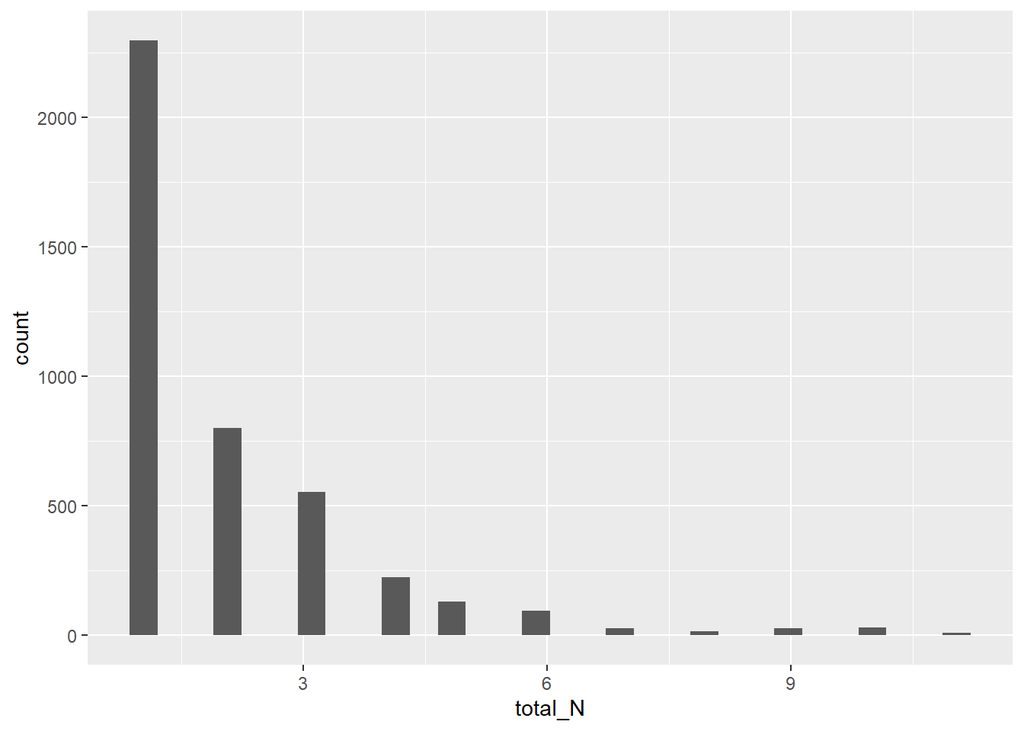

```r
Quick_Test_Admin <- Admin %>%
  filter(longitudinal==FALSE) %>%
  group_by(original_id) %>%
  arrange(age) %>%
  mutate(
    D = 1,
    trial_num = row_number(),
    total_N = sum(D), # Total number of trials per participant
    max_trial = ifelse(total_N == trial_num, yes=1, no=0
  )) %>%
  ungroup()

ggplot(Quick_Test_Admin, aes(x=total_N)) + geom_histogram()
```

```r
Quick_Test_Admin %>%
  group_by(total_N) %>%
  count()
```

| total_N | n |
| --- | --- |
| 1 | 2297 |
| 2 | 800 |
| 3 | 555 |
| 4 | 224 |
| 5 | 130 |
| 6 | 96 |
| 7 | 28 |
| 8 | 16 |
| 9 | 27 |
| 10 | 30 |

[output cut: 1 more lines]

Make sure I’ve selected latest administration.

```r
Quick_Test_Admin %>%
  filter(max_trial ==1) %>%
  summarise(
    Mean= mean(age),
    Min= min(age),
    max = max(age)
  )
```

| Mean | Min | max |
| --- | --- | --- |
| 23.3124 | 16 | 30 |

```r
Quick_Test_Admin %>%
  filter(max_trial ==1) %>%
  filter( age < 19) %>%
  count()
```

| n |
| --- |
| 559 |

```r
Quick_Test_Admin %>%
  filter(trial_num ==1) %>%
  summarise(
    Mean= mean(age),
    Min= min(age),
    max = max(age)
  )
```

| Mean | Min | max |
| --- | --- | --- |
| 21.74039 | 16 | 30 |

```r
Quick_Test_Admin %>%
  filter(trial_num==1) %>%
  filter( age < 19) %>%
  count()
```

| n |
| --- |
| 901 |

Ok, that did what I wanted it to do, so now we’ll make a new dataset that only has the last administration for each value of original id.

```r
Admin2 <- Admin %>%
  filter(longitudinal==FALSE) %>%
  group_by(original_id) %>%
  arrange(age) %>%
   mutate(
    D = 1,
    trial_num = row_number(),
    total_N = sum(D),
    max_trial = ifelse(total_N == trial_num, yes=1, no=0)
    ) %>%
  ungroup(original_id) %>%
  filter(max_trial==1)

N_dropped <- Admin %>%
  filter(longitudinal==FALSE) %>%
  group_by(original_id) %>%
  arrange(age) %>%
   mutate(
    D = 1,
    trial_num = row_number(),
    total_N = sum(D),
    max_trial = ifelse(total_N == trial_num, yes=1, no=0)
    ) %>%
  ungroup(original_id) %>%
  filter(max_trial==0) %>%
  nrow()
```

## 1.1 Make Grammatical Complexity Data

```r
Complex <- Admin2 %>% # start with new admin data set
  left_join(.,Inst, by="data_id") %>%
  left_join(., Item, by="num_item_id") %>%
  filter(type == "combine" | # to drop non-combiners
           type == "complexity" # to calculate complexity scores.
         ) %>%
  mutate(
    out = ifelse(value=="complex" | value=="sometimes" | value=="produces", yes=1,
                 no = ifelse(value=="often", yes=2, no =0))
  )

N_complexity_items = nrow(filter(Item, type == "combine" |
           type == "complexity"))

nrow(Complex) == (N_total - N_long - N_dropped)*N_complexity_items
```

```
## [1] TRUE
```

```r
Dropped_long <- N_long + N_dropped # dropped because of both definitions of longitudinal
```

```r
Complex$complexity_category <- ifelse(Complex$complexity_category == "", yes=Complex$type, no=Complex$complexity_category)
```

```r
Complex_short_with_ids_all <- Complex %>%
  dplyr::select(data_id, value, out, complexity_category, num_item_id) %>%
  mutate(
    label = str_c(complexity_category, num_item_id)
  ) %>%
  pivot_wider(id_cols=data_id, names_from = "label", values_from="out") %>%
  dplyr::select(starts_with(c("data_id", "combine", "morphology", "syntax")))

Complex_short_with_ids <- Complex_short_with_ids_all %>%
  drop_na()

N_NA <- nrow(Complex_short_with_ids_all) - nrow(Complex_short_with_ids)

nrow(Complex_short_with_ids) == N_total - Dropped_long - N_NA
```

```
## [1] TRUE
```

```r
Complex_short_grammatical <- Complex_short_with_ids %>%
  filter(combine760 > 0) %>%
  dplyr::select(starts_with(c("morphology", "syntax"))) # need to get rid of participant names for IRT models.

N_nog <- nrow(filter(Complex_short_with_ids, combine760 == 0))

nrow(Complex_short_grammatical) == N_total - Dropped_long - N_NA - N_nog
```

```
## [1] TRUE
```

##Make vocab data set.

```r
Vocab <- Admin2 %>% # Start with new administration dataset.
  left_join(.,Inst, by="data_id") %>%
  left_join(., Item, by="num_item_id") %>%
  filter(type == "word"
         ) %>%
  mutate(
    out = ifelse(value=="produces", yes=1, no =0)
    )

N_vocab = nrow(filter(Item, type == "word"))

nrow(Vocab) == (N_total - Dropped_long)*N_vocab
```

```
## [1] TRUE
```

```r
Vocab_short_with_ids_all <- Vocab %>%
  filter(lexical_category == "nouns" | lexical_category == "predicates") %>%
  dplyr::select(data_id, value, out, definition) %>%
  pivot_wider(id_cols=data_id, names_from = "definition", values_from="out")

Vocab_short_with_ids <- Vocab_short_with_ids_all %>%
  drop_na()


N_NA_vocab <- nrow(Vocab_short_with_ids_all) - nrow(Vocab_short_with_ids)

Vocab_short <- Vocab_short_with_ids %>%
  dplyr::select(-"data_id") # dataset for IRT can't have IDs

nrow(Vocab_short_with_ids) == N_total - Dropped_long - N_NA_vocab  #Not yet updated
```

```
## [1] TRUE
```

#Combine the two datasets

```r
full <- full_join(
  Complex_short_with_ids, Vocab_short_with_ids, by="data_id"
) %>%
  filter(combine760 > 0) %>%
  dplyr::select(-c("data_id", "combine760")) %>%
  drop_na()

nrow(full)/2187 # size of new dataset relative to the one in the prior analysis
```

```
## [1] 0.8573388
```

# 2 Some quick checks of dimensionality.

```r
full_tetra <- tetrachoric(full)
```

[output not shown]

[output not shown]

[output not shown]

[output not shown]

[output not shown]

[output not shown]

[output not shown]

[output not shown]

[output not shown]

[output not shown]

[output not shown]

[output not shown]

[output not shown]

[output not shown]

[output not shown]

[output not shown]

[output not shown]

[output not shown]

[output not shown]

[output not shown]

[output not shown]

[output not shown]

[output not shown]

[output not shown]

[output not shown]

[output not shown]

[output not shown]

[output not shown]

[output not shown]

[output not shown]

```r
rho <- full_tetra$rho
```

```r
fa.parallel(rho, fa="fa", fm="minres", cor="poly", n.obs = 1875)
```

```
## In smc, smcs < 0 were set to .0
## In smc, smcs < 0 were set to .0
## In smc, smcs < 0 were set to .0
```

```
## The determinant of the smoothed correlation was zero.
## This means the objective function is not defined.
## Chi square is based upon observed residuals.
```

```
## The determinant of the smoothed correlation was zero.
## This means the objective function is not defined for the null model either.
## The Chi square is thus based upon observed correlations.
```

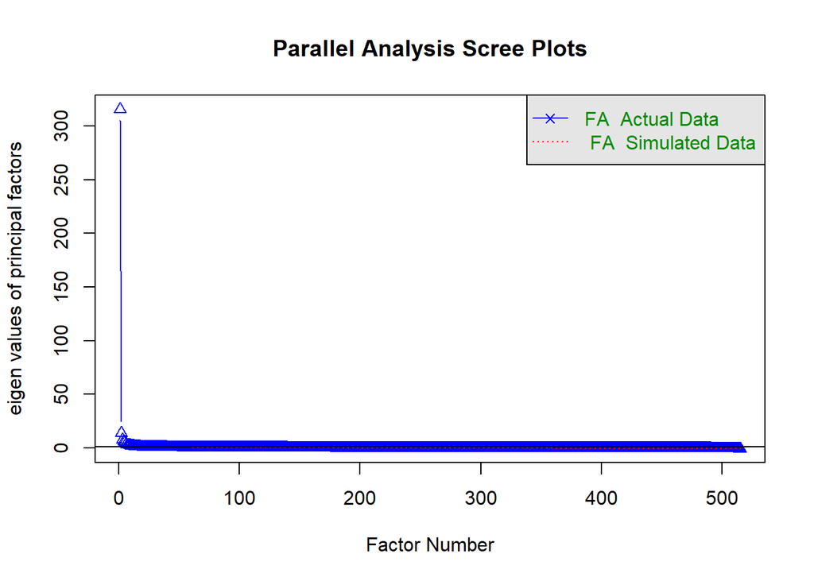

```
## Parallel analysis suggests that the number of factors =  20  and the number of components =  NA
```

```r
vss(rho, fa="fa", fm="minres", cor="poly", n.obs = 1875)
```

[output not shown]

[output not shown]

[output not shown]

[output not shown]

[output not shown]

[output not shown]

[output not shown]

[output not shown]

[output not shown]

[output not shown]

[output not shown]

[output not shown]

[output not shown]

[output not shown]

[output not shown]

[output not shown]

[output not shown]

[output not shown]

[output not shown]

[output not shown]

[output not shown]

[output not shown]

[output not shown]

[output not shown]

[output not shown]

[output not shown]

[output not shown]

[output not shown]

[output not shown]

[output not shown]

[output not shown]

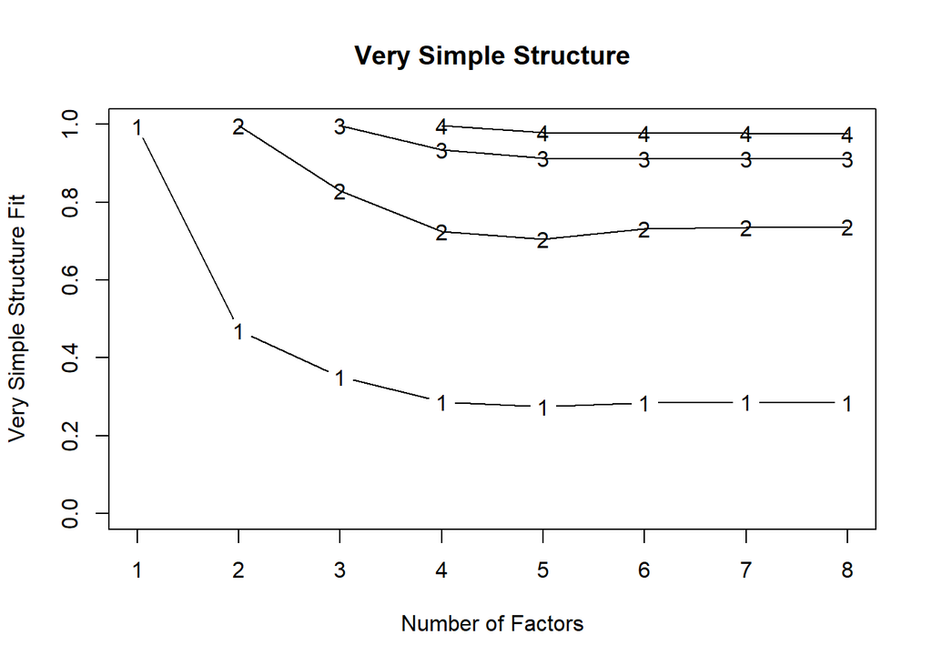

```
##
## Very Simple Structure
## Call: vss(x = rho, fm = "minres", n.obs = 1875, cor = "poly", fa = "fa")
## VSS complexity 1 achieves a maximimum of 0.99  with  1  factors
## VSS complexity 2 achieves a maximimum of 1  with  2  factors
##
## The Velicer MAP achieves a minimum of 0  with  8  factors
## BIC achieves a minimum of  -729454  with  8  factors
## Sample Size adjusted BIC achieves a minimum of  -321964  with  8  factors
##
## Statistics by number of factors
##   vss1 vss2    map    dof  chisq prob sqresid  fit RMSEA     BIC   SABIC
## 1 0.99 0.00 0.0104 131840 873693    0     514 0.99 0.055 -119901  298953
## 2 0.47 1.00 0.0067 131326 535412    0     315 1.00 0.041 -454308  -37087
## 3 0.35 0.83 0.0057 130813 427214    0     251 1.00 0.035 -558640 -143049
## 4 0.29 0.72 0.0049 130301 355614    0     209 1.00 0.030 -626382 -212417
## 5 0.27 0.71 0.0042 129790 299847    0     177 1.00 0.026 -678297 -265956
## 6 0.29 0.73 0.0039 129280 272858    0     161 1.00 0.024 -701443 -290722
## 7 0.29 0.74 0.0038 128771 254953    0     150 1.00 0.023 -715512 -306408
## 8 0.29 0.74 0.0037 128263 237183    0     140 1.00 0.021 -729454 -321964
##   complex eChisq  SRMR eCRMS    eBIC
## 1     1.0 808116 0.040 0.040 -185478
## 2     1.8 455701 0.030 0.030 -534019
## 3     2.4 347573 0.026 0.027 -638281
## 4     2.8 276890 0.024 0.024 -705106
## 5     3.1 222613 0.021 0.021 -755532
## 6     3.1 197768 0.020 0.020 -776533
## 7     3.2 182032 0.019 0.019 -788433
## 8     3.3 166564 0.018 0.019 -800073
```

#Fit IRT model Try MIRT model.

```r
#m1 <- mirt(full, 1, "2PL")
#saveRDS(m1, "combined_irt_output/re_test/m1.rds")
m1 <-  readRDS("combined_irt_output/re_test/m1.rds")
```

Get factor scores

```r
fscores <- fscores(m1, use_dentype_estimate=TRUE)[,1]
```

Exploratory Detect

```r
full2 <- data.frame(full)
```

##Confirmatory DETECT: Grammar vs Vocab

```r
dtct <- c(rep(1, 37), rep(2, 478))

conf <- conf.detect(full2, fscores, dtct)
```

```
## -----------------------------------------------------------
## Confirmatory DETECT Analysis
## Conditioning on 1 Score
## Bandwidth Scale: 1.1
## Pairwise Estimation of Conditional Covariances
## ...........................................................
## Nonparametric ICC estimation
##  5% 10% 15% 20% 25% 30% 35% 40% 45% 50%
## 55% 60% 65% 70% 75% 80% 85% 90% 95%
## ...........................................................
## Nonparametric Estimation of conditional covariances
##  5% 10% 15% 20% 25% 30% 35% 40% 45% 50%
## 55% 60% 65% 70% 75% 80% 85% 90% 95%
## -----------------------------------------------------------
##           unweighted weighted
## DETECT         0.103    0.103
## ASSI           0.072    0.072
## RATIO          0.245    0.245
## MADCOV100      0.420    0.420
## MCOV100        0.069    0.069
```

DETECT is less than .2. No evidence of the dimensional structure with vocabulary and grammar.

Exploratory detect to look for any other form of multidimensionality.

```r
d1 <- expl.detect(full2, fscores, nclusters=2)
```

```
## Pairwise Estimation of Conditional Covariances
## ...........................................................
## Nonparametric ICC estimation
##  5% 10% 15% 20% 25% 30% 35% 40% 45% 50%
## 55% 60% 65% 70% 75% 80% 85% 90% 95%
## ...........................................................
## Nonparametric Estimation of conditional covariances
##  5% 10% 15% 20% 25% 30% 35% 40% 45% 50%
## 55% 60% 65% 70% 75% 80% 85% 90% 95%
## Pairwise Estimation of Conditional Covariances
## ...........................................................
## Nonparametric ICC estimation
##  5% 10% 15% 20% 25% 30% 35% 40% 45% 50%
## 55% 60% 65% 70% 75% 80% 85% 90% 95%
## ...........................................................
## Nonparametric Estimation of conditional covariances
##  5% 10% 15% 20% 25% 30% 35% 40% 45% 50%
## 55% 60% 65% 70% 75% 80% 85% 90% 95%
##
##
## DETECT (unweighted)
##
## Optimal Cluster Size is  2  (Maximum of DETECT Index)
##
##   N.Cluster N.items N.est N.val size.cluster DETECT.est ASSI.est RATIO.est
## 1         2     515   937   938      189-326      0.293    0.408     0.595
##   MADCOV100.est MCOV100.est DETECT.val ASSI.val RATIO.val MADCOV100.val
## 1         0.492       0.091      0.222    0.299     0.482         0.461
##   MCOV100.val
## 1       0.094
```

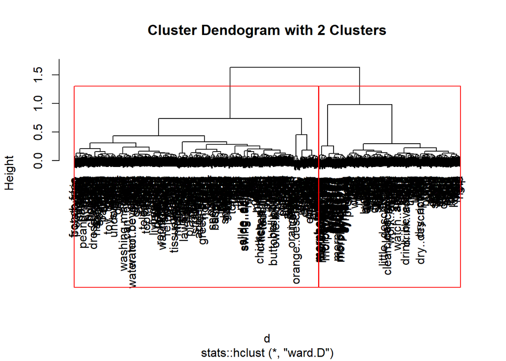

Some evidence of multidimensionality. Let’s look at which items belong to each dimension.

```r
options(max.print=2000)
d1
```

```
## $detect.unweighted
##     DETECT.val  ASSI.val RATIO.val MADCOV100.val MCOV100.val
## Cl2   0.222258 0.2986891 0.4822945     0.4608347  0.09425026
##
## $detect.weighted
##     DETECT.val  ASSI.val RATIO.val MADCOV100.val MCOV100.val
## Cl2   0.222258 0.2986891 0.4822945     0.4608347  0.09425026
##
## $clusterfit
##
## Call:
## stats::hclust(d = d, method = "ward.D")
##
## Cluster method   : ward.D
## Number of objects: 515
```

[output cut: 522 more lines]

Looks like, mostly grammar and predicates on dimension 1, and mostly nouns on dimension 2.